# Métodos Cuantitativos

**Clase 08 - Introducción a Pruebas de hipótesis**  
Unidad II: Test de Hipótesis y Regresión Lineal

## Introducción

- En estadística, una **hipótesis es una afirmación o declaración** sobre una propiedad de una población.
- Una **prueba de hipótesis** es un **procedimiento diseñado para evaluar la validez de una hipótesis** relacionada con una característica poblacional.

## Introducción

- La **característica de la población** mencionada suele referirse al valor de un parámetro poblacional. Por ejemplo:
  - $\mu \lt 25.2 °C$: La temperatura media en una ciudad específica es menor que $25.2 °C$.
  - $p \gt 0.5$: Más de la mitad de los consumidores se sienten a gusto con una determinada marca.
  - $\sigma = 15$: La desviación estándar de las puntuaciones de IQ de los estudiantes universitarios es de $15$.

## Introducción

- En cada uno de estos ejemplos, **el investigador formula una hipótesis sobre la población en estudio**. Al hacerlo, **realiza una afirmación** que luego **intentará confirmar o refutar**, enfocándose en uno o más parámetros poblacionales.
- Generalmente, **el investigador no dispone de toda la información de la población**, por lo que **debe recurrir a muestras para evaluar la veracidad de su hipótesis**.

## ¿Qué veremos hoy?

- **Fundamentos de la prueba de hipótesis**
- Valor crítico
- Prueba de una cola
- Valor-p
- Principales pruebas estadísticas

## Prueba de hipótesis

## Prueba de hipótesis

- El procedimiento implica plantear dos hipótesis:
  - $H_0$: Hipótesis nula (generalmente asociada a situaciones de no cambio)
  - $H_1$: Hipótesis alternativa (generalmente asociada a situación efectiva de cambio)
- Una prueba de hipótesis se basa en evidencia empírica y en distribuciones de probabilidad, para determinar si la **hipótesis nula $H_0$** es una afirmación razonable.

## Prueba de hipótesis

En general, una prueba de hipótesis tiene pasos ordenados a seguir:

1. Se establecen $H_0$ y $H_1$.
2. Se selecciona el nivel de significancia.
3. Se identifica el estadístico de prueba.
4. Se formula una regla para tomar decisiones.
5. Se toma una muestra; se llega a una decisión:
- No se rechaza la hipótesis nula.
- Se rechaza la hipótesis nula.

## Prueba de hipótesis

**Entonces, ¿qué es $H_0$ y $H_1$?**

- $H_0$ es la hipótesis nula, la cual representa la afirmación de que *no existe efecto* o *no hay diferencia* en los parámetros involucrados.
- $H_1$ es la hipótesis alternativa, la cual como investigadores conjeturamos, donde establecemos el efecto a evaluar.

## Prueba de hipótesis

Consideremos, por ejemplo, un estudio sobre el rendimiento académico en la asignatura de Métodos Cuantitativos entre estudiantes de la UST y la UDP.

- $H_0$: **No hay diferencia en el rendimiento académico** entre los estudiantes de la UST y los de la UDP en Métodos Cuantitativos.
- $\mu_{ust} = \mu_{udp}$
- $H_1$: Los estudiantes de la UST **muestran un rendimiento académico diferente** al de los estudiantes de la UDP en Métodos Cuantitativos.
- $\mu_{ust} \neq \mu_{udp}$
- Este tipo de pruebas son llamadas **de dos colas**.

## Prueba de hipótesis

Consideremos, por ejemplo, un estudio sobre el rendimiento académico en la asignatura de Métodos Cuantitativos entre estudiantes de la UST y la UDP.

- $H_0$: Los estudiantes de la UST **no muestran un rendimiento académico superior** que los estudiantes de la UDP en Métodos Cuantitativos.
- $\mu_{ust} \leq \mu_{udp}$
- $H_1$: Los estudiantes de la UST **muestran un rendimiento académico superior** al de los estudiantes de la UDP en Métodos Cuantitativos.
- $\mu_{ust} \gt \mu_{udp}$
- Este tipo de pruebas son llamadas **de una cola**.

## Prueba de hipótesis

- Tanto la aceptación como el rechazo de $H_0$ dependen de los resultados de evidencia empírica muestral, lo cual puede estar sujeto a **posibles errores asociados**.

## Prueba de hipótesis: Error Tipo I

- Error Tipo I: $P(\text{rechazar }H_0/H_0 \text{ es verdadera})$
- La probabilidad Tipo I se denota como $\alpha$, la cual corresponde al **nivel de significancia** de la prueba de hipótesis.
- El **valor-p** es la probabilidad, asumiendo verdadera la hipótesis nula, de observar un resultado al menos tan extremo como el obtenido.

## Prueba de hipótesis: Error Tipo II

- Error Tipo II: $P(\text{no rechazar }H_0/H_0 \text{ es falsa})$
- Se denota $\beta$ al Error Tipo II en una prueba de hipótesis teniendo en cuenta el nivel de significancia $\alpha$.
- El complemento $1 - \beta$ se conoce como la potencia de la prueba.
- **Potencia**: Es la probabilidad de que la prueba rechace correctamente la hipótesis nula.

## Prueba de hipótesis: Errores de decisión

**Entonces, ¿qué es el Error de Tipo I?**

Rechazar la hipótesis nula ($H_0$) cuando en realidad esta es verdadera.

**Entonces, ¿qué es el Error de Tipo II?**

No rechazar la hipótesis nula ($H_0$) cuando en realidad esta era falsa.

## Prueba de hipótesis: Errores de decisión

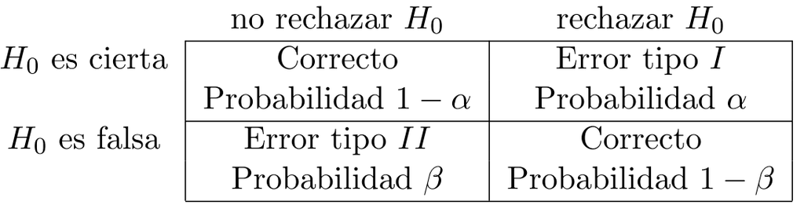

## Prueba de hipótesis: Criterio de decisión

Supongamos que queremos determinar si el promedio de la asignatura de Métodos Cuantitativos de los alumnos de la UST es igual a $55$.

- Para realizar la prueba de hipótesis, formulamos las siguientes inferencias respecto a la población:
  - $H_0: \mu = 55$
  - $H_1: \mu \neq 55$
- Con los datos muestrales disponibles, podemos decidir si rechazamos o no rechazamos $H_0$.

## Prueba de hipótesis: Criterio de decisión

Supongamos que al calcular la media muestral del curso, obtenemos una nota de $56$.

- ¿Se puede concluir que la media poblacional no es $55$?
- **Probablemente no**. Esta diferencia podría deberse a un error de muestreo.
- En este caso, la diferencia se consideraría *estadísticamente insignificante*. El desafío radica en determinar qué tan grande debe ser una diferencia para considerarla estadísticamente significativa.

## ¿Qué veremos hoy?

- Fundamentos de la prueba de hipótesis
- **Valor crítico**
- Prueba de una cola
- Valor-p
- Principales pruebas estadísticas

## Valor crítico

## Prueba de hipótesis: Valor crítico

- Recordando las distribuciones, podemos aplicar la fórmula Z para el caso muestral:
- $Z = \frac{\overline{X} - \mu}{\frac{\sigma}{\sqrt{n}}}$
- Si la varianza poblacional es desconocida, podemos utilizar la varianza muestral.
- La regla empírica indica que el 95% de las veces la media muestral esta a **1.96 desviaciones de la media poblacional**.

## Prueba de hipótesis: Valor crítico

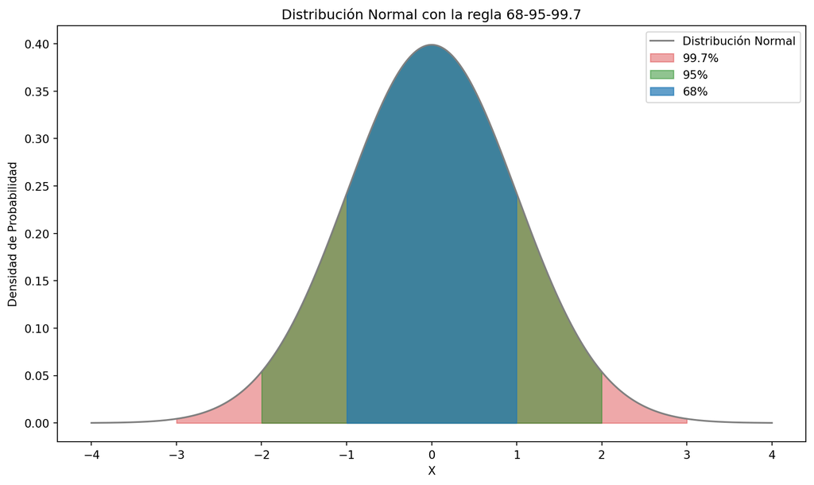

```python
import matplotlib.pyplot as plt
import numpy as np
import scipy.stats as stats

mu = 0
sigma = 1

x = np.linspace(mu - 4*sigma, mu + 4*sigma, 1000)
y = stats.norm.pdf(x, mu, sigma)

plt.figure(figsize=(10, 6))
plt.plot(x, y, label='Distribución Normal', color="gray")

plt.fill_between(x, y, where=np.abs(x-mu) <= 3*sigma, color='tab:red', alpha=0.4, label='99.7%')
plt.fill_between(x, y, where=np.abs(x-mu) <= 2*sigma, color='forestgreen', alpha=0.5, label='95%')
plt.fill_between(x, y, where=np.abs(x-mu) <= sigma, color='tab:blue', alpha=0.7, label='68%')

plt.title('Distribución Normal con la regla 68-95-99.7')
plt.xlabel('X')
plt.ylabel('Densidad de Probabilidad')
plt.legend()

plt.tight_layout()
plt.show()
```

## Prueba de hipótesis: Valor crítico

- La regla empírica establece que para una distribución normal:
  - Aproximadamente el **68% de los datos caen dentro de una desviación estándar de la media**.
  - Aproximadamente el **95% de los datos caen dentro de dos desviaciones estándar de la media**.
  - Aproximadamente el **99.7% de los datos caen dentro de tres desviaciones estándar de la media**.

## Prueba de hipótesis: Valor crítico

- Entonces, cuando afirmamos que “*el 95% de las veces, la media muestral está a 1.96 desviaciones estándar de la media poblacional*”, nos referimos a:
  - Si repetimos el muestreo muchas veces, el 95% de las medias muestrales estarán dentro del rango de **1.96 desviaciones estándar por encima o por debajo de la media poblacional**.

## Prueba de hipótesis: Valor crítico

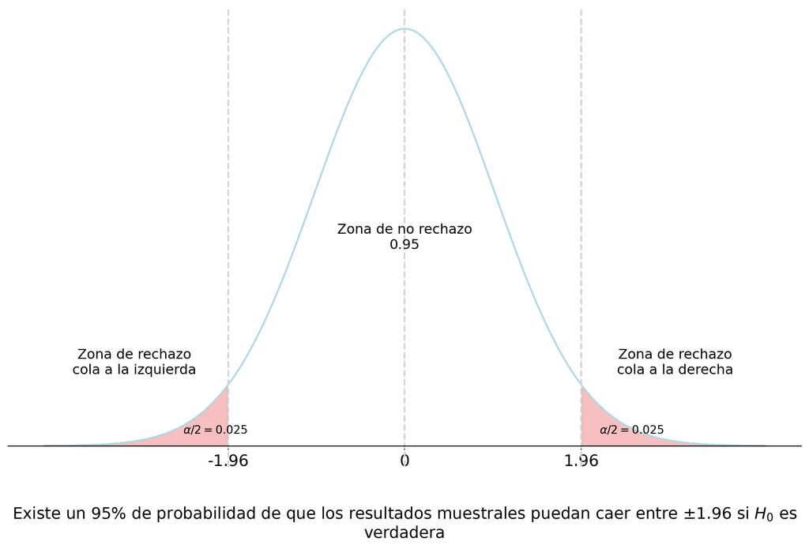

```python
import matplotlib.pyplot as plt
import numpy as np
import scipy.stats as stats

mu = 0
sigma = 1
x = np.linspace(mu - 4*sigma, mu + 4*sigma, 1000)
y = stats.norm.pdf(x, mu, sigma)

z_critical = 1.96

plt.figure(figsize=(10, 6))
plt.plot(x, y, label='Distribución Normal', color='lightblue')

plt.fill_between(x, y, where=(x <= -z_critical), color='lightcoral', alpha=0.5, label='Zona de rechazo cola a la izquierda')
plt.fill_between(x, y, where=(x >= z_critical), color='lightcoral', alpha=0.5, label='Zona de rechazo cola a la derecha')
plt.fill_between(x, y, where=(x > -z_critical) & (x < z_critical), color='white', alpha=0.5, label='Zona de no rechazo')

plt.axvline(-z_critical, color='lightgray', linestyle='--')
plt.axvline(z_critical, color='lightgray', linestyle='--')

plt.text(-z_critical - 0.5, 0.02, '$\\alpha/2 = 0.025$', fontsize=10, verticalalignment='top')
plt.text(z_critical + 0.2, 0.02, '$\\alpha/2 = 0.025$', fontsize=10, verticalalignment='top')

plt.axvline(mu, color='lightgray', linestyle='--')
plt.text(0, max(y)*0.5, 'Zona de no rechazo\n0.95', fontsize=12, verticalalignment='center', horizontalalignment='center')
plt.text(-3, max(y)*0.2, 'Zona de rechazo\ncola a la izquierda', fontsize=12, verticalalignment='center', horizontalalignment='center')
plt.text(3, max(y)*0.2, 'Zona de rechazo\ncola a la derecha', fontsize=12, verticalalignment='center', horizontalalignment='center')

plt.gca().spines['left'].set_visible(False)
plt.gca().spines['right'].set_visible(False)
plt.gca().spines['top'].set_visible(False)
plt.gca().spines['bottom'].set_position('zero')

plt.xticks([-1.96, 0, 1.96], ['-1.96', '0', '1.96'], fontsize=14)
plt.gca().tick_params(axis='y', which='both', left=False, right=False, labelleft=False)

plt.figtext(0.5, -0.1, 'Existe un 95% de probabilidad de que los resultados muestrales puedan caer entre $\pm$1.96 si $H_0$ es verdadera',
            wrap=True, horizontalalignment='center', fontsize=14)

plt.tight_layout()
plt.show()
```

## Prueba de hipótesis: Valor crítico

- Valores críticos de $Z\pm1.96$ permiten establecer una regla de decisión que diga si se rechaza la hipótesis nula o no:
  - No se rechaza $H_0$ si los valores $Z$ están entre $\pm1.96$.
  - Se rechaza $H_0$ si el valor de $Z$ es menor que $-1.96$ o mayor que $1.96$.

## Prueba de hipótesis: Valor crítico

- Retomando el ejemplo del promedio de la asignatura en la UST:
  - $H_0: \mu = 55$
  - $H_1: \mu \neq 55$
- Ahora, supongamos que después de recolectar los datos, obtenemos los siguientes resultados:
  - Media muestral $(\overline{X}): 56$
  - Desv. estándar de la población $(\sigma): 3$ (suponiendo que es conocida)
  - Tamaño de la muestra $(n): 30$

## Prueba de hipótesis: Valor crítico

- Primero, calculamos el error estándar de la media (la desviación estándar de la distribución muestral):
  - Error estándar $= \frac{\sigma}{\sqrt{n}} = \frac{3}{\sqrt{30}} \approx 0.5477$
- Luego calculamos el puntaje $Z$:
  - $Z = \frac{56-55}{0.5477} \approx 1.825$
- Ahora, comparamos este valor $Z$ con los valores críticos para un nivel de significancia ($\alpha$) del 5% (nivel de confianza del 95%). Para una prueba de dos colas, los valores críticos son $\pm1.96$.

## Prueba de hipótesis: Valor crítico

- La regla empírica y los valores críticos nos indican que:
  - Si el valor $Z$ calculado está entre $-1.96$ y $1.96$, no rechazamos $H_0$.
  - Si el valor $Z$ calculado está fuera de este rango, rechazamos $H_0$.
- En nuestro ejemplo, el valor $Z$ es $1.825$, que está dentro del rango de $-1.96$ y $1.96$. Por lo tanto, **fallamos en rechazar $H_0$.**

## Prueba de hipótesis: Valor crítico

- Esto significa que la diferencia observada entre la media muestral (56) y la media poblacional (55) podría deberse al error de muestreo y no es lo suficientemente grande como para considerarse estadísticamente significativa.
- En resumen, aunque la media muestral es 56, no tenemos suficiente evidencia para concluir que la media poblacional es diferente de 55 con un nivel de confianza del 95%.

## Digresión: ¿Por qué 1.96?

```python
from scipy.stats import norm

# establecer el nivel de significancia
alpha = 0.05

# calcular el área de la cola
area_cola = 1 - (alpha / 2)

# parámetros distribución normal
mu = 0
sigma = 1

# obtener el valor del estadístico crítico
z_critical = norm.ppf(area_cola)

# imprimir valor
print(round(z_critical, 3))
```

```
1.96
```

## ¿Qué veremos hoy?

- Fundamentos de la prueba de hipótesis
- Valor crítico
- **Prueba de una cola**
- Valor-p
- Principales pruebas estadísticas

## Prueba de hipótesis: Prueba de una cola

- En algunos casos, solo nos interesa un extremo de la distribución, ya sea el inferior o el superior, por ejemplo:
  - Un restaurante de comida fresca no se interesa en saber qué tan rápidos son sus proveedores, sólo si toman demasiado tiempo.
  - Un minorista se alarmará sólo si sus ingresos son demasiado bajos, ventas altas no son un problema.

## Prueba de hipótesis: Prueba de una cola

$$H_0: \mu \leq 55 \text{ vs } H_1: \mu \gt 55$$

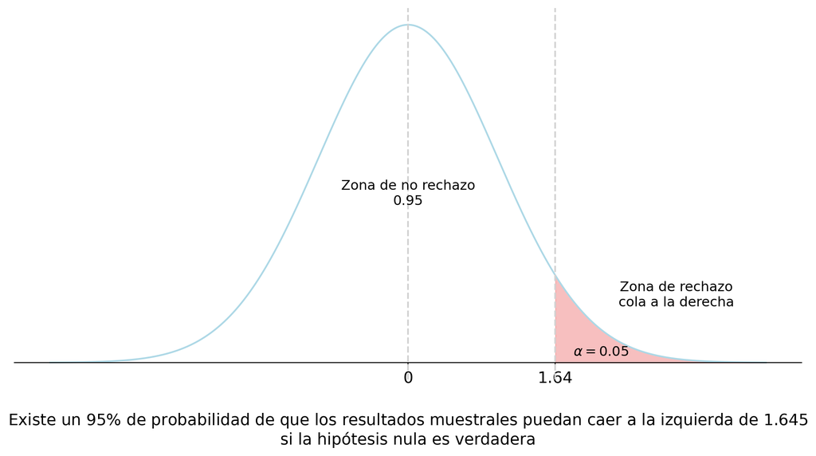

```python
import matplotlib.pyplot as plt
import numpy as np
import scipy.stats as stats

mu = 0
sigma = 1
x = np.linspace(mu - 4*sigma, mu + 4*sigma, 1000)
y = stats.norm.pdf(x, mu, sigma)

alpha = 0.05
z_critical = stats.norm.ppf(1 - alpha)

plt.figure(figsize=(10, 5))
plt.plot(x, y, label='Distribución Normal', color='lightblue')

plt.fill_between(x, y, where=(x >= z_critical), color='lightcoral', alpha=0.5, label='Zona de rechazo cola a la derecha')
plt.fill_between(x, y, where=(x < z_critical), color='white', alpha=0.5, label='Zona de no rechazo')
plt.axvline(z_critical, color='lightgray', linestyle='--')

plt.text(z_critical + 0.2, 0.02, f'$\\alpha = {alpha}$', fontsize=12, verticalalignment='top')
plt.axvline(mu, color='lightgray', linestyle='--')
plt.text(0, max(y)*0.5, 'Zona de no rechazo\n0.95', fontsize=12, verticalalignment='center', horizontalalignment='center')

plt.text(3, max(y)*0.2, 'Zona de rechazo\ncola a la derecha', fontsize=12, verticalalignment='center', horizontalalignment='center')

plt.gca().spines['left'].set_visible(False)
plt.gca().spines['right'].set_visible(False)
plt.gca().spines['top'].set_visible(False)
plt.gca().spines['bottom'].set_position('zero')

plt.xticks([0, z_critical], ['0', f'{z_critical:.2f}'], fontsize=14)
plt.gca().tick_params(axis='y', which='both', left=False, right=False, labelleft=False)

plt.figtext(0.5, -0.1, 'Existe un 95% de probabilidad de que los resultados muestrales puedan caer a la izquierda de $1.645$ si la hipótesis nula es verdadera',
            wrap=True, horizontalalignment='center', fontsize=14)

plt.tight_layout()
plt.show()
```

## Prueba de hipótesis: Prueba de una cola

$$H_0: \mu \geq 55 \text{ vs } H_1: \mu \lt 55$$

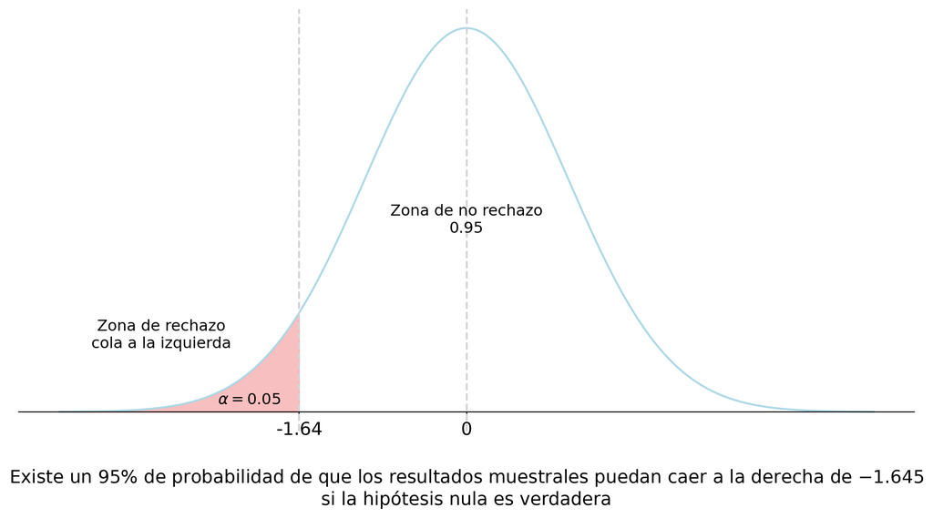

```python
mu = 0
sigma = 1
x = np.linspace(mu - 4*sigma, mu + 4*sigma, 1000)
y = stats.norm.pdf(x, mu, sigma)

alpha = 0.05
z_critical = stats.norm.ppf(alpha)

plt.figure(figsize=(10, 5))
plt.plot(x, y, label='Distribución Normal', color='lightblue')

plt.fill_between(x, y, where=(x <= z_critical), color='lightcoral', alpha=0.5, label='Zona de rechazo cola a la izquierda')
plt.fill_between(x, y, where=(x > z_critical), color='white', alpha=0.5, label='Zona de no rechazo')
plt.axvline(z_critical, color='lightgray', linestyle='--')

plt.text(z_critical - 0.8, 0.02, f'$\\alpha = {alpha}$', fontsize=12, verticalalignment='top')

plt.axvline(mu, color='lightgray', linestyle='--')
plt.text(0, max(y)*0.5, 'Zona de no rechazo\n0.95', fontsize=12, verticalalignment='center', horizontalalignment='center')

plt.text(-3, max(y)*0.2, 'Zona de rechazo\ncola a la izquierda', fontsize=12, verticalalignment='center', horizontalalignment='center')

plt.gca().spines['left'].set_visible(False)
plt.gca().spines['right'].set_visible(False)
plt.gca().spines['top'].set_visible(False)
plt.gca().spines['bottom'].set_position('zero')

plt.xticks([z_critical, 0], [f'{z_critical:.2f}', '0'], fontsize=14)
plt.gca().tick_params(axis='y', which='both', left=False, right=False, labelleft=False)

plt.figtext(0.5, -0.1, 'Existe un 95% de probabilidad de que los resultados muestrales puedan caer a la derecha de $-1.645$ si la hipótesis nula es verdadera',
            wrap=True, horizontalalignment='center', fontsize=14)

plt.tight_layout()
plt.show()
```

## Prueba de hipótesis: Prueba de una cola

- $Z = \frac{56-55}{\frac{3}{\sqrt{30}}} \approx 1.825$
- Para un nivel de significancia de $\alpha$ = 0.05 en una cola derecha, el valor crítico de $Z$ es aproximadamente $1.645$.
- Como $Z \approx 1.825$ es mayor $1.645$, rechazamos $H_0$.
- Con un nivel de significancia del 5%, tenemos suficiente evidencia para rechazar $H_0$ y concluir que el promedio de la asignatura es significativamente mayor a $55$.

## Prueba de hipótesis: Diferencias en resultados

- La diferencia en los resultados se debe a la posición y el tamaño de las zonas de rechazo en las dos pruebas:
  - En la prueba de dos colas, el área total de $\alpha$ se divide entre las dos colas, lo que hace que los valores críticos sean más extremos ($\pm1.96$)
  - En la prueba de una cola, todo el $\alpha$ se concentra en una cola, haciendo que el valor crítico sea menos extremo ($1.645$).

## Prueba de hipótesis: Diferencias en resultados

- Por lo tanto, una media muestral que no sea suficientemente extrema para rechazar $H_0$ en una prueba de dos colas puede ser suficiente para rechazar $H_0$ en una prueba de una cola debido a la diferencia en los valores críticos.

## Prueba de hipótesis: Criterio de decisión

- Hasta ahora hemos aprendido cómo formular y evaluar hipótesis utilizando estadísticos de prueba y valores críticos.
- Sin embargo, hay otro enfoque muy utilizado en pruebas de hipótesis: el **valor-p**.

## ¿Qué veremos hoy?

- Fundamentos de la prueba de hipótesis
- Valor crítico
- Prueba de una cola
- **Valor-p**
- Principales pruebas estadísticas

## Prueba de hipótesis: Valor-p

## Prueba de hipótesis: Valor-p

- El valor-p es la probabilidad de obtener un resultado tan extremo como el observado, o más extremo, bajo la suposición de que la hipótesis nula ($H_0$) es verdadera.
- El **valor-p nos ayuda a determinar la significancia de nuestros resultados sin depender de un valor crítico específico**.

## Prueba de hipótesis: Valor-p

### **¿Cómo interpretar el valor-p?**

- **Valor-p pequeño (por ejemplo, menor que un nivel de significancia, como $\alpha = 0.05$)**: Indica que los resultados observados son poco probables bajo la suposición de que la hipótesis nula ($H_0$) es verdadera. Esto sugiere que hay suficiente evidencia para considerar rechazar $H_0$.
- **Valor-p grande (por ejemplo, mayor que el nivel de significancia $\alpha = 0.05$)**: Indica que los resultados observados son consistentes con la hipótesis nula ($H_0$). Esto sugiere que no hay suficiente evidencia en los datos para rechazar $H_0$.

## Prueba de hipótesis: Valor-p

- En una prueba de hipótesis, comparamos el valor-p con un umbral de significancia ($\alpha$) para tomar una decisión:
  - Si el valor-p $\leq \alpha$, rechazamos $H_0$.
  - Si el valor-p $\gt \alpha$, no rechazamos $H_0$.

## Pruebas de hipótesis en Python

### Prueba de dos colas

```python
from scipy.stats import ttest_1samp

# datos
media_poblacional = 55
alpha = 0.05

# creamos una muestra simulada para realizar el test
muestra = np.array([52, 50, 55, 51, 58, 59, 55, 53, 56, 57, 58, 59, 55, 56, 57, 58,
                    55, 54, 53, 52, 51, 50, 49, 60, 60, 61, 62, 63, 64, 65]
)

# prueba de dos colas
# H0: media_muestral = 55 vs H1: media_muestral != 55
t_stat, p_value = ttest_1samp(muestra, media_poblacional, alternative='two-sided')

# resultados
print("H0: media_muestral = 55 vs H1: media_muestral != 55")
print(f"Valor-p: {p_value}")

if p_value < alpha:
    print(f"Con una significancia de {alpha} y un valor-p = {round(p_value, 2)} -> Rechazamos la hipótesis nula")
else:
    print(f"Con una significancia de {alpha} y un valor-p = {round(p_value, 2)} -> No rechazamos la hipótesis nula")
```

```
H0: media_muestral = 55 vs H1: media_muestral != 55
Valor-p: 0.12063570605176656
Con una significancia de 0.05 y un valor-p = 0.12 -> No rechazamos la hipótesis nula
```

## Pruebas de hipótesis en Python

### Prueba de una cola

```python
from scipy.stats import ttest_1samp

# datos
media_poblacional = 55
alpha = 0.05

# creamos una muestra simulada para realizar el test
muestra = np.array([52, 50, 55, 51, 58, 59, 55, 53, 56, 57, 58, 59, 55, 56, 57, 58,
                    55, 54, 53, 52, 51, 50, 49, 60, 60, 61, 62, 63, 64, 65]
)

# prueba de una cola
# H0: media_muestral <= 55 vs H1: media_muestral > 55
t_stat, p_value = ttest_1samp(muestra, media_poblacional, alternative='greater')

# resultados
print("H0: media_muestral <= 55 vs H1: media_muestral > 55")
print(f"Valor-p: {p_value}")

if p_value < alpha:
    print(f"Con una significancia de {alpha} y un valor-p = {round(p_value, 2)} -> Rechazamos la hipótesis nula")
else:
    print(f"Con una significancia de {alpha} y un valor-p = {round(p_value, 2)} -> No rechazamos la hipótesis nula")
```

```
H0: media_muestral <= 55 vs H1: media_muestral > 55
Valor-p: 0.06031785302588328
Con una significancia de 0.05 y un valor-p = 0.06 -> No rechazamos la hipótesis nula
```

## Pruebas de hipótesis en Python

### Prueba de una cola

```python
from scipy.stats import ttest_1samp

# datos
media_poblacional = 55
alpha = 0.05

# creamos una muestra simulada para realizar el test
muestra = np.array([52, 50, 55, 51, 58, 59, 55, 53, 56, 57, 58, 59, 55, 56, 57, 58,
                    55, 54, 53, 52, 51, 50, 49, 60, 60, 61, 62, 63, 64, 65]
)

# prueba de una cola
# H0: media_muestral >= 55 vs H1: media_muestral < 55
t_stat, p_value = ttest_1samp(muestra, media_poblacional, alternative='less')

# resultados
print("H0: media_muestral >= 55 vs H1: media_muestral < 55")
print(f"Valor-p: {p_value}")

if p_value < alpha:
    print(f"Con una significancia de {alpha} y un valor-p = {round(p_value, 2)} -> Rechazamos la hipótesis nula")
else:
    print(f"Con una significancia de {alpha} y un valor-p = {round(p_value, 2)} -> No rechazamos la hipótesis nula")
```

```
H0: media_muestral >= 55 vs H1: media_muestral < 55
Valor-p: 0.9396821469741168
Con una significancia de 0.05 y un valor-p = 0.94 -> No rechazamos la hipótesis nula
```

## Valor-p

**¡No olvidar!**

- Si el valor-p $\leq \alpha$, rechazamos $H_0$.
- Si el valor-p $\gt \alpha$, no rechazamos $H_0$.

[figure not shown]

# Prueba de hipótesis: Parámetros

## Prueba de hipótesis: Parámetros

Son tres parámetros poblacionales a los que les aplicaremos el procedimiento de una prueba de hipótesis:

| Población | estadístico muestral |
| --- | --- |
| $\mu$ | $\overline{X}$ |
| $P$ | $\hat{P}$ |
| $\sigma$ | $S$ |

## Prueba de hipótesis: media poblacional $\mu$

- Hipótesis:
  - $H_0: \mu = \mu_0$
  - $H_1:$
    - $\mu \neq \mu_0$
    - $\mu \lt \mu_0$
    - $\mu \gt \mu_0$
- Recolectar datos:
  - $\alpha, n, \overline{X}, S \text{ (o } \sigma \text{ si se conoce)}$

## Prueba de hipótesis: proporción poblacional $p$

- Hipótesis:
  - $H_0: p = p_0$
  - $H_1:$
    - $p \neq p_0$
    - $p \lt p_0$
    - $p \gt p_0$
- Recolectar datos:
  - $\alpha, n, \hat{p}$

## Prueba de hipótesis: varianza poblacional $\sigma^2$

- Hipótesis:
  - $H_0: \sigma^2 = \sigma^2_0$
  - $H_1:$
    - $\sigma^2 \neq \sigma^2_0$
    - $\sigma^2 \lt \sigma^2_0$
    - $\sigma^2 \gt \sigma^2_0$
- Recolectar datos:
  - $\alpha, n, S^2$

## ¿Qué veremos hoy?

- Fundamentos de la prueba de hipótesis
- Valor crítico
- Prueba de una cola
- Valor-p
- **Principales pruebas estadísticas**

## Prueba t

## Prueba t

- La prueba t de Student es una prueba estadística que se utiliza para comparar la media de una muestra con la media de una población o para comparar las medias de dos muestras diferentes.
- Se usa principalmente cuando las muestras son pequeñas y las distribuciones de los datos son aproximadamente normales.

## Prueba t: ¿Cuándo usar?

1. **Comparar una muestra con una media conocida**: Si tenemos una muestra de datos y necesitamos saber si su media es significativamente diferente de una media conocida o esperada.
2. **Comparar dos muestras independientes**: Si tenemos dos grupos diferentes y necesitamos saber si sus medias son significativamente diferentes.
3. **Comparar muestras relacionadas**: Si tenemos dos conjuntos de datos relacionados, como antes y después de un tratamiento en el mismo grupo de personas.

## Prueba t: Tipos

1. **Prueba t para una muestra**: Compara la media de una sola muestra con una media conocida.
2. **Prueba t para dos muestras independientes**: Compara las medias de dos grupos independientes.
3. **Prueba t para muestras relacionadas (pareadas)**: Compara las medias de dos conjuntos de datos que están relacionados (por ejemplo, mediciones antes y después en el mismo grupo).

## Prueba t: Ejemplo

- Supongamos que tenemos una muestra de estudiantes que han realizado una prueba y buscamos saber si su promedio es diferente de 75 puntos (la media esperada).

## Prueba t: Ejemplo

1. Hipótesis:
- $H_0: \mu = 75$
- $H_0: \mu \neq 75$
2. Recopilar los datos y calcular la media y la desviación estándar de la muestra.
3. Calcular el valor t.
4. Calcular el valor p utilizando el valor t y la distribución t de Student.
5. Comparar el valor p con el nivel de significancia ($\alpha$)

## Prueba Z

## Prueba Z

- El test Z es una prueba estadística que se utiliza para comparar la media de una muestra con la media de una población **cuando la desviación estándar de la población es conocida**, o para comparar las medias de dos muestras grandes.
- Se usa principalmente cuando las muestras son grandes ($n \gt 30$) y las distribuciones de los datos son aproximadamente normales.

## Prueba Z: ¿Cuándo usar?

1. **Comparar una muestra con una media conocida**: Si tenemos una muestra de datos y necesitamos saber si su media es significativamente diferente de una media conocida o esperada.
2. **Comparar dos muestras independientes**: Si tenemos dos grupos diferentes y necesitamos saber si sus medias son significativamente diferentes (por ejemplo, hombres vs. mujeres en un estudio).

## Prueba Z: Tipos

1. **Prueba Z para una muestra**: Compara la media de una sola muestra con una media conocida.
2. **Prueba Z para dos muestras independientes**: Compara las medias de dos grupos independientes.

## Prueba Z: Ejemplo

- Supongamos que queremos saber si la altura promedio de los hombres en una ciudad es diferente de 175 cm (la media esperada).
- Sabemos que la desviación estándar de la altura de los hombres en esta ciudad es 10 cm.
- Tomamos una muestra aleatoria de 1000 hombres y encontramos que la media de la muestra es 176.5 cm.

## Prueba Z: Ejemplo

1. Hipótesis:
- $H_0: \mu = 175$
- $H_0: \mu \neq 175$
2. Recopilar los datos y calcular la media de la muestra.
3. Calcular el valor Z.
4. Calcular el valor p utilizando el valor Z y la distribución normal estándar.
5. Comparar el valor p con el nivel de significancia ($\alpha$)

## Prueba Chi-cuadrado

## Prueba Chi-cuadrado

- El test Chi-cuadrado es una prueba estadística que se utiliza para determinar si existe una diferencia significativa entre las frecuencias observadas y las frecuencias esperadas en una o más categorías.
- Se usa principalmente en datos categóricos.

## Prueba Chi-cuadrado: ¿Cuándo usar?

1. **Prueba de independencia**: Para determinar si hay una asociación significativa entre dos variables categóricas.
2. **Prueba de bondad de ajuste**: Para determinar si una distribución observada difiere significativamente de una distribución esperada.

## Prueba Chi-cuadrado: Tipos

1. **Prueba Chi-cuadrado de independencia**: Evalúa si dos variables categóricas son independientes.
2. **Prueba Chi-cuadrado de bondad de ajuste**: Evalúa si la distribución de una variable categórica sigue una distribución esperada.

## Prueba Chi-cuadrado: Ejemplo

- Supongamos que queremos saber si hay una asociación entre el hábito de fumar (fumador/no fumador) y el resultado de una prueba de salud (positivo/negativo) en una muestra grande de personas.

## Prueba Chi-cuadrado: Ejemplo

1. **Hipótesis**:
- $H_0$: El hábito de fumar y el resultado de la prueba de salud son independientes.
- $H_1$: El hábito de fumar y el resultado de la prueba de salud no son independientes.
2. Recopilar los datos y organizar en una tabla de contingencia.
3. Calcular el estadístico Chi-cuadrado ($\chi^2$)
4. Calcular el valor p
5. Comparar el valor p con el nivel de significancia ($\alpha$).

## Prueba Shapiro-Wilk

## Prueba Shapiro-Wilk

- El Test de Shapiro-Wilk es una prueba estadística que se utiliza para determinar si un conjunto de datos se distribuye de manera normal.
- Es especialmente útil en tamaños de muestra pequeños (menos de 50 muestras), aunque puede usarse con muestras de hasta 2000.

## Prueba Shapiro-Wilk: ¿Cuándo usar?

1. **Antes de otros tests**: Algunos tests estadísticos, como el ANOVA y las pruebas t, asumen que los datos siguen una distribución normal. El Test de Shapiro-Wilk puede ayudar a validar esta suposición.
2. **Análisis exploratorio de datos**: Utilizado comúnmente en la fase inicial de análisis para asegurar que la distribución de los datos no viola los supuestos de normalidad.

## Prueba Shapiro-Wilk: Ejemplo

- Supongamos que tenemos una muestra de las puntuaciones obtenidas en una prueba de IQ, y deseamos verificar si estas puntuaciones se distribuyen normalmente.

## Prueba Shapiro-Wilk: Ejemplo

1. Hipótesis:
- $H_0$: Los datos siguen una distribución normal.
- $H_1$: Los datos no siguen una distribución normal.
2. Recopilar los datos y observar la distribución.
3. Calcular el estadístico de Shapiro-Wilk y el valor-p asociado.
4. Comparar el valor-p con el nivel de significancia ($\alpha$).

## Prueba Shapiro-Wilk: Interpretación

- Si el valor p $\leq 0.05$, se rechaza la hipótesis nula ($H_0$), lo que indica que los datos no se ajustan a una distribución normal.
- Si el valor p $\gt 0.05$, no hay evidencia suficiente para rechazar la hipótesis nula, lo que sugiere que los datos pueden considerarse normalmente distribuidos.

## Resumen

## Resumen

En general, el proceso de una prueba de hipótesis es:

1. Establecer las hipótesis.
2. Aplicar el test.
3. Determinar el nivel de significancia $\alpha$ (generalmente se usa 5%).
4. Comparar el valor-p del test con el nivel de significancia.
5. Rechazar o no rechazar $H_0$.

## Resumen

- **Prueba t**: Comparar la media de una muestra con la media de una población o para comparar las medias de dos muestras diferentes.
- **Prueba Z**: Comparar la media de una muestra con la media de una población **cuando la desviación estándar de la población es conocida**, o para comparar las medias de dos muestras grandes.

## Resumen

- **Prueba Chi-cuadrado**: Determinar si existe una diferencia significativa entre las frecuencias observadas y las frecuencias esperadas en una o más categorías.
- **Prueba Shapiro-Wilk**: Determinar si un conjunto de datos se distribuye de manera normal.